# La paradoja de San Petersburgo

La paradoja de San Petersburgo es un ejemplo de problema en el que falla el método de Montecarlo (la paradoja es llamada así debido a que el matemático Daniel Bernoulli publicó en 1738 el primer análisis y propuesta de solución del problema en las Actas de la Academia de Ciencias de San Petersburgo).

Consideremos el siguiente juego de azar:

1. Se le pide al jugador que apueste una cierta cantidad de dinero $C$.
2. Se lanza una y otra vez una moneda no trucada hasta que sale cara.
3. El jugador recibe $2^{x}$€, donde $x$ es la tirada en la que ha salido cara por primera vez.

¿Hasta qué cantidad de dinero debería el jugador estar dispuesto a apostar para jugar a este juego? Teniendo en cuenta que la ganancia del jugador es $G = 2^{x} - C$, para tratar de responder a esta pregunta usaremos el método de Montecarlo para estimar $\mu = \mathbb{E}[2^{X + 1}]$, donde $X$ representa el número de cruces antes de la primera cara y, por tanto, $X \sim \mathrm{Geom}\bigl(\frac{1}{2}\bigr)$.

```r
estimacion_Montecarlo <- function() {
  n <- 1e5
  valores <- replicate(n, {
    x <- rgeom(1, prob = 1 / 2)
    2^(x + 1)
  })
  estimacion <- mean(valores)
  probabilidad_cobertura <- 0.95
  alfa <- 1 - probabilidad_cobertura
  percentil <- qnorm(1 - alfa / 2)
  error_estandar <- sqrt(var(valores) / n)
  intervalo_confianza <- estimacion + c(-1, 1) * error_estandar * percentil
  list(
    Estimacion = estimacion,
    Intervalo = intervalo_confianza,
    Longitud = diff(intervalo_confianza)
  )
}
```

Desafortunadamente, podemos comprobar que cada vez que apliquemos el método obtenemos una estimación totalmente distinta.

```r
estimacion_Montecarlo()
```

```
## $Estimacion
## [1] 355.2007
##
## $Intervalo
## [1] -302.4799 1012.8813
##
## $Longitud
## [1] 1315.361
```

```r
estimacion_Montecarlo()
```

```
## $Estimacion
## [1] 14.17524
##
## $Intervalo
## [1] 12.66637 15.68411
##
## $Longitud
## [1] 3.017733
```

```r
estimacion_Montecarlo()
```

```
## $Estimacion
## [1] 24.97284
##
## $Intervalo
## [1] 12.93677 37.00891
##
## $Longitud
## [1] 24.07214
```

Los resultados obtenidos son consecuencia de que el problema tiene esperanza (y, por tanto, varianza) infinita.
$$\begin{equation*}
\mu
= \mathbb{E}[2^{X + 1}]
= \sum_{x = 0}^{\infty} 2^{x + 1} \mathbb{P}(X = x)
= \sum_{x = 0}^{\infty} 2^{x + 1} 2^{-(x + 1)}
= \infty
\end{equation*}$$

La paradoja es entonces que, a pesar de que la ganancia esperada del jugador es mayor que la cantidad exigida para entrar en el juego, y por lo tanto se debería aceptar sea cual sea esa cantidad, una persona racional no estaría dispuesta a jugar si la apuesta inicial es excesiva.

En efecto, asumiendo que $C$ es una potencia de $2$, se tiene que:
$$\begin{equation*}
\mathbb{P}(G > 0)
= \mathbb{P}(X \geq \log_{2} C)
= \sum_{x = \log_{2} C}^{\infty} \mathbb{P}(X = x)
= \sum_{x = \log_{2} C}^{\infty} 2^{-(x + 1)}
= \frac{1}{C}
\end{equation*}$$
por lo que la probabilidad de obtener una ganancia positiva disminuye a medida que aumenta la apuesta inicial, a pesar de que la ganancia esperada es infinita.

Un síntoma de que la esperanza a estimar es infinita se observa en el siguiente gráfico, que muestra la evolución de $\hat{\mu}_{n}$ con respecto a $n$.

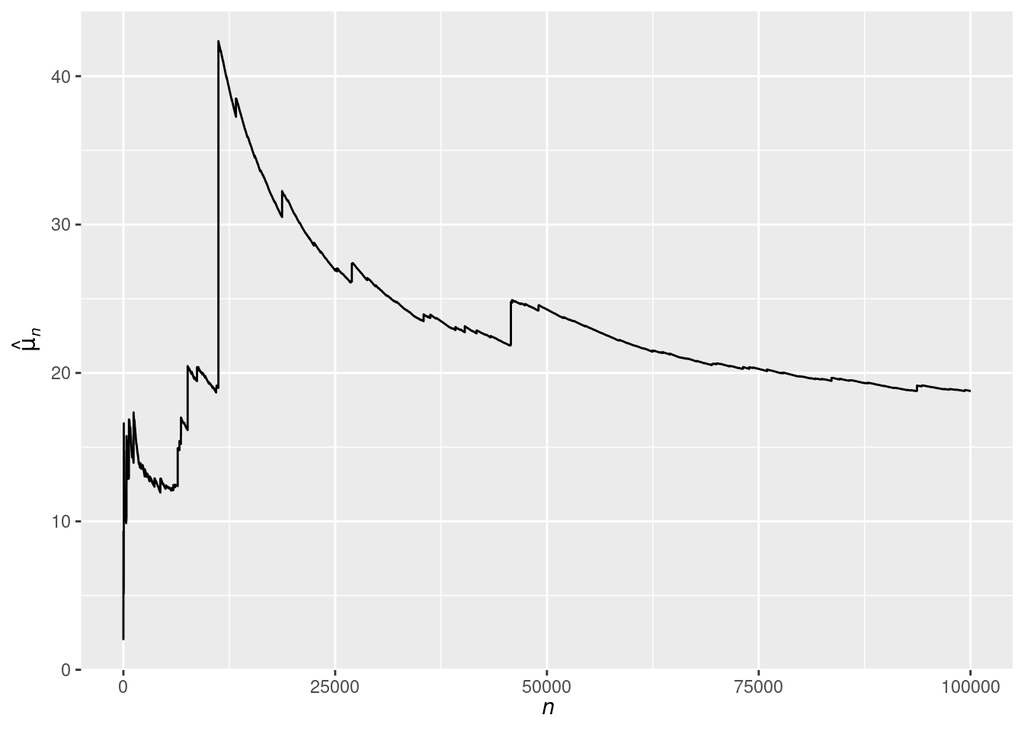

Los «saltos» que aparecen en el gráfico se producen cada vez que $2^{x_{n} + 1}$ es suficientemente grande y deben aparecer de forma continuada, ya que la ley fuerte de los grandes números sigue asegurando que $\mathbb{P}(\hat{\mu}_{n} \rightarrow \infty) = 1$. Sin embargo, puesto que todos los valores aleatorios $x_{i}$ son finitos, $\hat{\mu}_{n}$ es siempre finito. Por tanto, no es posible esperar a que $\hat{\mu}_{n} = \infty$ y entonces declarar que $\mu = \infty$.

Si modificamos el problema de tal forma que al jugador se le entreguen $x$€ cuando la primera cara se obtiene en la $x$-ésima tirada, entonces
$$\begin{equation*}
\mu
= \mathbb{E}[X + 1]
= \sum_{x = 0}^{\infty} (x + 1) \mathbb{P}(X = x)
= \sum_{x = 0}^{\infty} (x + 1) 2^{-(x + 1)}
= 2
\end{equation*}$$
y se tiene el siguiente gráfico de la evolución de $\hat{\mu}_{n}$ con respecto a $n$, en el que no aparecen esos «saltos».

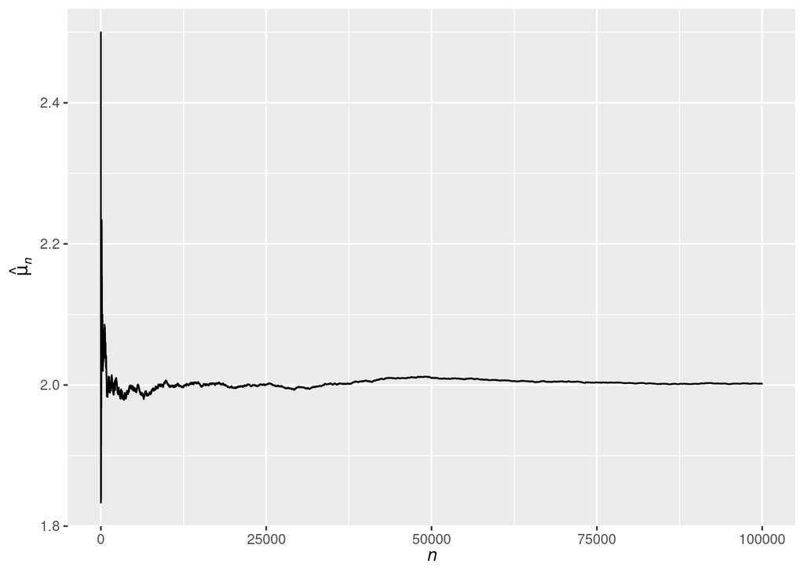

No obstante, es importante entender que gráficos como los anteriores únicamente proporcionan intuiciones acerca de si el valor de la esperanza es finito o infinito. Solo un razonamiento matemático formal puede proporcionar una respuesta concluyente.